# Replication of Horvat & Evans 2011

```r
pacman::p_load("tidyverse","readxl","foreign","skimr","fastDummies","kableExtra","MASS","sjPlot","webshot","knitr")
```

Datafile acquired in a email string from Horvat to Evans to the ultimate source of this aggregate file “Mass_Public_Surveys_1993-2007.dta” with Ksenia Northmore-Ball (Nov. 8th, 2020)

```r
# original data
df_origa <- readstata13::read.dta13("data/Mass_Public_Surveys_1993-2007.dta")
df_orig_labels <- readstata13::read.dta13("data/Mass_Public_Surveys_1993-2007.dta", generate.factors = T)

# original tables 1 & 2 from the article
Tbl1_orig <- read_xlsx("data/orig_tables.xlsx", sheet = "Tbl1", col_names = F)
```

```
## * `` -> ...1
## * `` -> ...2
## * `` -> ...3
## * `` -> ...4
## * `` -> ...5
## * ...
```

```r
Tbl2_orig <- read_xlsx("data/orig_tables.xlsx", sheet = "Tbl2", col_names = F)
```

```
## * `` -> ...1
## * `` -> ...2
## * `` -> ...3
## * `` -> ...4
## * `` -> ...5
## * ...
```

```r
# codebook
codebook <- read.csv("data/codebook.csv", header = T)
```

```r
Tbl1_orig <- Tbl1_orig[-c(1:3),]
colnames(Tbl1_orig) <- c("Variable","y93-96 a18-29","y93-96 a30-44","y93-96 a 45-59","y93-96 a60+","y07 18-29","y07 30-44","y07 45-59","y07 60+")

Tbl1_orig[,2:9] <- lapply(Tbl1_orig[,2:9], function (x) ifelse(is.na(x), "", x))

Tbl2_orig <- Tbl2_orig[-c(1:2),]

colnames(Tbl2_orig) <- c("Variable","y93-96 a18-29","y93-96 a30-44","y93-96 a 45-59","y93-96 a60+","y07 18-29","y07 30-44","y07 45-59","y07 60+")

Tbl2_orig[,2:9] <- lapply(Tbl2_orig[,2:9], function (x) ifelse(is.na(x), "", x))
```

| v270 Main source of income | Code |
| --- | --- |
| Earnings from employment (own or partner’s) | 1 |
| Pensions and benefits | 2 |
| Student stipend | 3 |
| Other state benefit | 4 |
| Interest from savings or property | 5 |
| Dependent on family/relatives | 6 |

| v200 Work Status | Code |
| --- | --- |
| in paid work (including self-employment) | 1 |
| full-time student | 2 |
| in military service | 3 |
| unemployed | 4 |
| permanently sick or disabled | 5 |
| completely retired from work | 6 |
| looking after the home | 7 |
| other | 8 |
| NA | 9 |
| demobilized | 10 |
| vacation without salary | 11 |

Education = “Education is measured by three categories: low, middle, and higher education. Low education means no educational qualifications beyond the compulsory level. Middle education corresponds to completed secondary education and higher education corresponds to completed further or university education.” (p. 713)

ISCED-97 0 pre-primary 1 primary/1st stage basic ed 2 lower secondary 3 upper secondary 4 post-secondary non-tertiary 5 1st stage tertiary 6 2nd stage tert

**v269 income per month** Income recoded into terciles by country-year (see footnote 3)

**Class**

“Social class is measured by a six-category version of the Erikson–Goldthorpe class schema (Erikson and Goldthorpe, 1992), based on occupational measures of class position: service class, routine non-manual workers, self-employed workers, manual supervisors and skilled manual workers, semi-skilled and unskilled manual workers, and farmers or agricultural workers. A residual category ‘never had a paying job’ denotes respondents whose social class was ambiguous or missing but who reported never having been in paid employment elsewhere in the survey. Women with missing social class data were classified according to their husband’s class. Previous research on Eastern Europe suggests that occupational measures of class position perform adequately in the Eastern European context and successfully differentiate individuals in terms of their level of income, their degree of economic security, and chances of economic advancement (Evans, 1997; Evans and Mills, 1999).”

Students dropped

**Age** cat_age: cross-temporally and cross-nationally consistent age categories: 1: -29; 2: 30-44; 3: 45-59; 4: 60+

```r
df_orig <- df_origa %>%
  mutate(stdliv_past5 = car::recode(v272, "8 = 3"), # don't knows were recoded into middle cat in original study
         stdliv_past5_di = car::recode(stdliv_past5, "c(1,2) = 1; c(4,5) = 2; c(3) = 3"),
         stdliv_next5 = car::recode(v273, "8 = 3"),
         stdliv_next5_di = car::recode(stdliv_next5, "c(1,2) = 1; c(4,5) = 2; c(3) = 3"),
         noway_future_improve = as.numeric(as.character(ifelse(v276 == "no any way", 1, 0))),
         mkt_econ_eval = car::recode(v4, "'dont know' = 3"),
         mkt_econ_eval_di = car::recode(mkt_econ_eval, "c('very positively','positively') = 1; c('negatively','very negatively') = 2; c('neither positively nor negatively') = 3"),
         student = ifelse(v200 == 2 | v200 == 9, NA, 0), # remove students and NA's
         wave = as.numeric(car::recode(year, "c('1993','1994','1995','1996') = '1993'; c('2007') = '2007'; c('1997','1998','2001','2002','2003','2004','2005','2006') = NA")),
         female = as.numeric(v298) - 1,
         pensions = ifelse(is.na(v270), NA, ifelse(v270==2, 1, 0)),
         unemployed = ifelse(v200 == 8, NA, ifelse(v200==4, 1, 0)),
         car_owner = ifelse(v262 ==1, 1, 0),
         education = car::recode(std_education, "c(0,1,2) = 1; c(3,4) = 2; c(5,6) = 3; c(99) = NA"), # some had 99 in the std_education variable still, made into primary
         education_a = car::recode(std_education, "c(1,2,95,96) = 1; c(3,4,5,6,8) = 2; c(7,9,10,11,12) = 3; c(98,99,14) = NA"), # 4 and 5 are questionable categories here
         education = ifelse(cntry == "russia" & year == 1996, education_a, education),
         # There is a problem with Russia in 1996, seems that it was not recoded into ISCED
         EGP6 = car::recode(rclass10, "'Missing in 93-03 data' = 8;'semi-unskilld manual' = 5; 'skilled manual' = 4; 'higher controllers' = 1;'lo controllers' = 1;  'routine nonmanual'= 2; 'sempl without empl' = 3; 'sempl with emp' = 4; 'selfempl farm' = 6; 'farm labor'=6; 'manual supervisor' = 4; 'Missing Occupation Code 07' = 8; 'Not ISKO codes' = 8; 'ISKO Coded - no match' = 8; 'Never had a paying job' = 7"),
         EGP6 = ifelse(EGP6 == 8 & r2class10 == "never had a paying job", "7", EGP6),
         EGP6 = ifelse(is.na(v201), EGP6, ifelse(v201 == "no", "7", EGP6)), # never had a paid job
         EGP6 = ifelse(EGP6 == 8, NA, EGP6)
         ) %>%
  group_by(cntry, year) %>%
  mutate(income = ifelse(is.na(v269), 4, ntile(v269, 3))) %>%
  ungroup()
# some weights are NA, replace with 1 (actually there are no weights for 1993, so this is not really helpful)
df_orig$weight <- ifelse(is.na(df_orig$v461), 1, df_orig$v461)

# create complete cases df
df_orig_complete <- df_orig[!is.na(df_orig["education"]),]
# df_orig_complete <- df_orig_complete[!is.na(df_orig_complete["income"]),]
df_orig_complete <- df_orig_complete[!is.na(df_orig_complete["EGP6"]),]
df_orig_complete <- df_orig_complete[!is.na(df_orig_complete["female"]),]
df_orig_complete <- df_orig_complete[!is.na(df_orig_complete["wave"]),]
df_orig_complete <- df_orig_complete[!is.na(df_orig_complete["student"]),]
df_orig_complete <- df_orig_complete[!is.na(df_orig_complete["pensions"]),]
df_orig_complete <- df_orig_complete[!is.na(df_orig_complete["unemployed"]),]
df_orig_complete <- df_orig_complete[!is.na(df_orig_complete["car_owner"]),]
df_orig_complete <- df_orig_complete[!is.na(df_orig_complete["stdliv_past5"]),]
df_orig_complete <- df_orig_complete[!is.na(df_orig_complete["stdliv_next5"]),]
df_orig_complete <- df_orig_complete[!is.na(df_orig_complete["mkt_econ_eval"]),]
df_orig_complete <- df_orig_complete[!is.na(df_orig_complete["noway_future_improve"]),]
# create factor dummies
df_orig_complete <- dummy_cols(df_orig_complete, select_columns = c("EGP6", "income", "education","stdliv_past5_di","stdliv_next5_di","mkt_econ_eval_di"))

#create new group ID
df_orig_complete$group <- df_orig_complete$cat_age + (100*df_orig_complete$wave)

# cases per group

cases <- df_orig_complete %>%
  group_by(group) %>%
  count() %>%
  ungroup() %>%
  dplyr::select(-group) %>%
  t()

  #df_orig <- select(df_orig, v201, rclass10, EGP6, everything())
```

Replicate Table 1

```r
# get weighted means by group
Tbl1_rep <- apply(df_orig_complete[,c("education_1","education_2","education_3","income_1","income_2","income_3","EGP6_1","EGP6_2","EGP6_3","EGP6_4","EGP6_5","EGP6_6","EGP6_7","female")], 2, function(x) {sapply(split(data.frame(df_orig_complete[,"weight"], x), df_orig_complete$group), function(y) weighted.mean(y[,2], w = y$weight))})

Tbl1_rep <- as.data.frame(t(round(Tbl1_rep*100, 0)))



Tbl1_rep[nrow(Tbl1_rep)+1,] <- cases

kable_styling(kable(Tbl1_rep))
```

|  | 199301 | 199302 | 199303 | 199304 | 200701 | 200702 | 200703 | 200704 |
| --- | --- | --- | --- | --- | --- | --- | --- | --- |
| education_1 | 29 | 26 | 39 | 62 | 26 | 42 | 38 | 72 |
| education_2 | 54 | 48 | 39 | 25 | 24 | 35 | 48 | 15 |
| education_3 | 17 | 25 | 22 | 13 | 50 | 23 | 15 | 12 |
| income_1 | 26 | 24 | 30 | 56 | 16 | 32 | 38 | 39 |
| income_2 | 34 | 35 | 34 | 31 | 27 | 31 | 42 | 45 |
| income_3 | 39 | 41 | 36 | 13 | 57 | 37 | 20 | 15 |
| EGP6_1 | 22 | 31 | 32 | 24 | 14 | 23 | 18 | 24 |
| EGP6_2 | 15 | 13 | 11 | 10 | 7 | 22 | 15 | 13 |
| EGP6_3 | 4 | 3 | 2 | 1 | 2 | 4 | 14 | 0 |
| EGP6_4 | 23 | 22 | 21 | 18 | 55 | 26 | 16 | 19 |
| EGP6_5 | 18 | 20 | 20 | 21 | 9 | 17 | 32 | 31 |
| EGP6_6 | 8 | 10 | 12 | 22 | 0 | 4 | 4 | 10 |
| EGP6_7 | 10 | 1 | 1 | 5 | 11 | 4 | 2 | 3 |
| female | 52 | 52 | 54 | 57 | 38 | 66 | 65 | 58 |
| 15 | 3827 | 7325 | 5766 | 5226 | 2086 | 3596 | 3876 | 3946 |

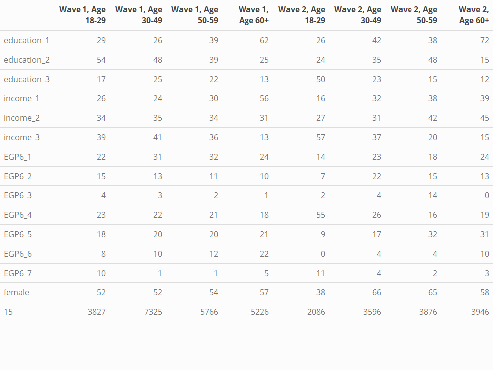

```r
Tbl1_rep_out <- kable_styling(kable(Tbl1_rep, col.names = c("Wave 1, Age 18-29","Wave 1, Age 30-49","Wave 1, Age 50-59","Wave 1, Age 60+","Wave 2, Age 18-29","Wave 2, Age 30-49","Wave 2, Age 50-59","Wave 2, Age 60+")))
save_kable(Tbl1_rep_out, file = "results/Tbl1_rep.htm")

webshot("results/Tbl1_rep.htm", file = "results/Tbl1_rep.png")
```

The results do not match very well, especially in the education category. Actually it appears that only 2007 has weights. Running Table 1 without weights changes very little. Therefore, a proper test requires hand coding by country; however, the country-specific education codes in the codebook for v198 are incorrect, e.g., I tested Bulgaria and Belarus 1993 and they have several extra codes than what is listed in the codebook provided. Therefore, this hand coding is not possible.

```r
# Tbl1_repn <- apply(df_orig_complete[,c("education_1","education_2","education_3","income_1","in# come_2","income_3","EGP6_1","EGP6_2","EGP6_3","EGP6_4","EGP6_5","EGP6_6","EGP6_7","female")],
# 2, function(x) {sapply(split(data.frame(df_orig_complete[,"weight"], x),
# df_orig_complete$group), function(y) mean(y[,2]))})

# Tbl1_repn <- as.data.frame(t(round(Tbl1_repn, 3)))

# Tbl1_repn[nrow(Tbl1_repn)+1,] <- cases
```

```r
# get weighted means by group
Tbl2_rep <- apply(df_orig_complete[,c("pensions","unemployed","car_owner")], 2, function(x) {sapply(split(data.frame(df_orig_complete[,"weight"], x), df_orig_complete$group), function(y) weighted.mean(y[,2], w = y$weight))})

Tbl2_rep <- as.data.frame(t(round(Tbl2_rep, 3)))

Tbl2_rep[nrow(Tbl2_rep)+1,] <- cases

kable_styling(kable(Tbl2_rep))
```

|  | 199301 | 199302 | 199303 | 199304 | 200701 | 200702 | 200703 | 200704 |
| --- | --- | --- | --- | --- | --- | --- | --- | --- |
| pensions | 0.019 | 0.027 | 0.222 | 0.861 | 0.015 | 0.054 | 0.220 | 0.938 |
| unemployed | 0.161 | 0.091 | 0.061 | 0.005 | 0.080 | 0.114 | 0.099 | 0.011 |
| car_owner | 0.366 | 0.435 | 0.402 | 0.218 | 0.366 | 0.533 | 0.622 | 0.282 |
| 4 | 3827.000 | 7325.000 | 5766.000 | 5226.000 | 2086.000 | 3596.000 | 3876.000 | 3946.000 |

```r
Tbl3_rep <- apply(df_orig_complete[,c("stdliv_past5_di_1","stdliv_past5_di_2","stdliv_next5_di_1","stdliv_next5_di_2","noway_future_improve","mkt_econ_eval_di_1","mkt_econ_eval_di_2")], 2, function(x) {sapply(split(data.frame(df_orig_complete[,"weight"], x), df_orig_complete$group), function(y) weighted.mean(y[,2], w = y$weight))})

Tbl3_rep <- as.data.frame(t(round(Tbl3_rep, 3)))

Tbl3_rep[nrow(Tbl3_rep)+1,] <- cases

kable_styling(kable(Tbl3_rep))
```

|  | 199301 | 199302 | 199303 | 199304 | 200701 | 200702 | 200703 | 200704 |
| --- | --- | --- | --- | --- | --- | --- | --- | --- |
| stdliv_past5_di_1 | 0.569 | 0.655 | 0.749 | 0.806 | 0.209 | 0.431 | 0.519 | 0.576 |
| stdliv_past5_di_2 | 0.200 | 0.157 | 0.087 | 0.049 | 0.683 | 0.312 | 0.247 | 0.106 |
| stdliv_next5_di_1 | 0.187 | 0.254 | 0.327 | 0.323 | 0.110 | 0.293 | 0.424 | 0.377 |
| stdliv_next5_di_2 | 0.366 | 0.291 | 0.225 | 0.161 | 0.708 | 0.320 | 0.239 | 0.132 |
| noway_future_improve | 0.096 | 0.159 | 0.354 | 0.735 | 0.121 | 0.158 | 0.289 | 0.812 |
| mkt_econ_eval_di_1 | 0.237 | 0.198 | 0.169 | 0.153 | 0.652 | 0.167 | 0.177 | 0.230 |
| mkt_econ_eval_di_2 | 0.467 | 0.540 | 0.572 | 0.542 | 0.219 | 0.575 | 0.550 | 0.506 |
| 8 | 3827.000 | 7325.000 | 5766.000 | 5226.000 | 2086.000 | 3596.000 | 3876.000 | 3946.000 |

Here I can reproduce Table 3 almost exactly, but only when I **do not use weights**, therefore, it is unclear what it means in the text when they claim that the descriptives are weighted.

```r
Tbl3_rep <- apply(df_orig_complete[,c("stdliv_past5_di_1","stdliv_past5_di_2","stdliv_next5_di_1","stdliv_next5_di_2","noway_future_improve","mkt_econ_eval_di_1","mkt_econ_eval_di_2")], 2, function(x) {sapply(split(data.frame(df_orig_complete[,"weight"], x), df_orig_complete$group), function(y) mean(y[,2], w = y$weight))})

Tbl3_rep <- as.data.frame(t(round(Tbl3_rep, 3)))

Tbl3_rep[nrow(Tbl3_rep)+1,] <- cases

kable_styling(kable(Tbl3_rep))
```

|  | 199301 | 199302 | 199303 | 199304 | 200701 | 200702 | 200703 | 200704 |
| --- | --- | --- | --- | --- | --- | --- | --- | --- |
| stdliv_past5_di_1 | 0.569 | 0.655 | 0.749 | 0.806 | 0.187 | 0.241 | 0.336 | 0.393 |
| stdliv_past5_di_2 | 0.200 | 0.157 | 0.087 | 0.049 | 0.485 | 0.421 | 0.302 | 0.198 |
| stdliv_next5_di_1 | 0.187 | 0.254 | 0.327 | 0.323 | 0.066 | 0.113 | 0.182 | 0.235 |
| stdliv_next5_di_2 | 0.366 | 0.291 | 0.225 | 0.161 | 0.525 | 0.431 | 0.308 | 0.187 |
| noway_future_improve | 0.096 | 0.159 | 0.354 | 0.735 | 0.039 | 0.078 | 0.245 | 0.669 |
| mkt_econ_eval_di_1 | 0.237 | 0.198 | 0.169 | 0.153 | 0.382 | 0.353 | 0.301 | 0.247 |
| mkt_econ_eval_di_2 | 0.467 | 0.540 | 0.572 | 0.542 | 0.328 | 0.362 | 0.416 | 0.432 |
| 8 | 3827.000 | 7325.000 | 5766.000 | 5226.000 | 2086.000 | 3596.000 | 3876.000 | 3946.000 |

### Table A.1

Just to check the sample

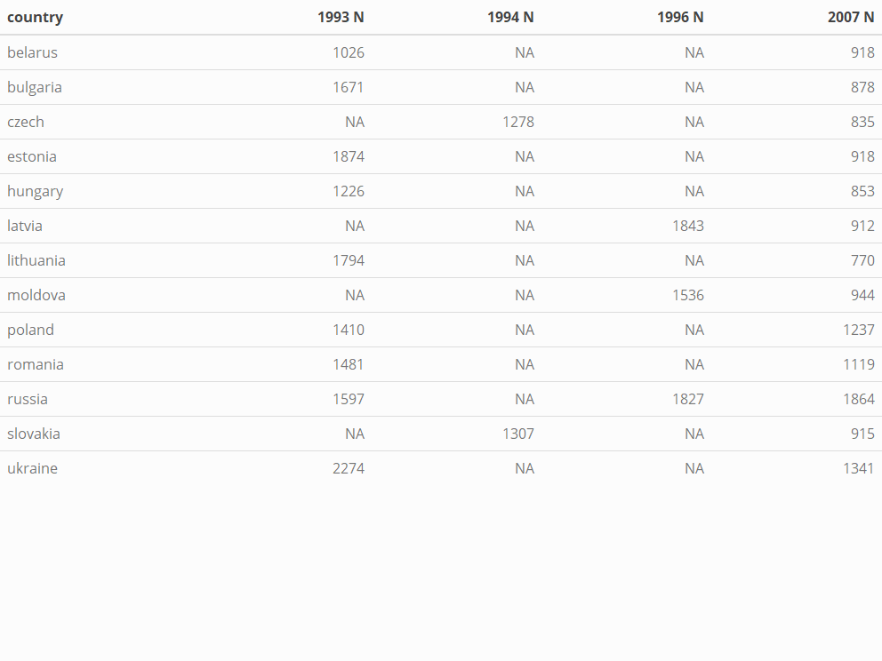

```r
TblA1_repa <- df_orig_complete %>%
  subset(year == 1993) %>%
  group_by(cntry) %>%
  count(cntry) %>%
  ungroup()

TblA1_repb <- df_orig_complete %>%
  subset(year == 1994) %>%
  group_by(cntry) %>%
  count(cntry) %>%
  ungroup()

TblA1_repc <- df_orig_complete %>%
  subset(year == 1996) %>%
  group_by(cntry) %>%
  count(cntry) %>%
  ungroup()

TblA1_repd <- df_orig_complete %>%
  subset(year == 2007) %>%
  group_by(cntry) %>%
  count(cntry) %>%
  ungroup()

TblA1_rep <- left_join(TblA1_repd, TblA1_repa, by = "cntry")
TblA1_rep <- left_join(TblA1_rep, TblA1_repb, by = "cntry")
TblA1_rep <- left_join(TblA1_rep, TblA1_repc, by = "cntry")

TblA1_rep[,1:5] <- TblA1_rep[,c(1,3,4,5,2)]

colnames(TblA1_rep) <- c("country", "1993 N","1994 N","1996 N","2007 N")

TblA1r <- kable_styling(kable(TblA1_rep))

save_kable(TblA1r, file = "results/TblA1_rep.htm")

webshot("results/TblA1_rep.htm", file = "results/TblA1_rep.png")
```

## 5% Prereg Analysis

Here I select out 5% of the sample at random and run their models as part of the pre-registration.

```r
set.seed(90210)

df_orig_complete <- df_orig_complete %>%
  mutate(rand = runif(NROW(df_orig_complete$y1)),
         p5 = ifelse(rand > 0.05, NA, 1))

df_orig_complete_5 <- df_orig_complete[!is.na(df_orig_complete["p5"]),]
```

```r
Tbl5_m1 <- polr(factor(stdliv_next5) ~ factor(cat_age) + factor(wave) + factor(cat_age)*factor(wave), data = df_orig_complete_5, Hess = T)

Tbl5_m2 <- polr(factor(stdliv_next5) ~ factor(cat_age) + factor(wave) + factor(cat_age)*factor(wave) + female + factor(education) + factor(EGP6) + factor(income), data = df_orig_complete_5, Hess = T)

Tbl5_m3 <- polr(factor(stdliv_next5) ~ factor(cat_age) + factor(wave) + factor(cat_age)*factor(wave) + female + factor(education) + factor(EGP6) + factor(income) + pensions + unemployed + car_owner + factor(cntry), data = df_orig_complete_5, Hess = T)

tab_model(Tbl5_m1, Tbl5_m2, Tbl5_m3, p.style = "stars", show.ci = F, show.loglik = T,  pred.labels = c("k1","k2","k3","k4","Age 30-44","Age 44-59","Age >60","Year 2007","Age 30-44*year'07", "Age 44-59*year'07", "Age >60*year'07", "Female", "Educ mid", "Educ high" ,"EGP: routine non-man", "EGP: Self", "EGP: Skilled", "EGP: Unskilled", "EGP: Farmers", "EGP: Never had a job", "Income mid", "Income high","Income missing", "Pensions and benefits","Unemployed", "Car","bulgaria", "czech", "estonia", "hungary","latvia", "lithuania", "moldova","poland", "romania", "russia","slovakia", "ukraine"), file = "results/Tbl5_rep.htm")
```

factor(stdliv_next5)

factor(stdliv_next5)

factor(stdliv_next5)

Predictors

Odds Ratios

Odds Ratios

Odds Ratios

k1

0.08 ***

0.09 ***

0.10 ***

k2

0.20 ***

0.22 ***

0.26 ***

k3

1.72 ***

1.93 **

2.44 **

k4

27.71 ***

32.20 ***

43.24 ***

Age 30-44

0.76

0.74

0.76

Age 44-59

0.46 ***

0.46 ***

0.46 ***

Age >60

0.34 ***

0.40 ***

0.45 ***

Year 2007

2.45 ***

2.72 ***

2.91 ***

Age 30-44*year’07

0.63

0.57

0.54 *

Age 44-59*year’07

0.65

0.58

0.57

Age >60*year’07

0.61

0.53 *

0.51 *

Female

0.86

0.89

Educ mid

1.12

1.07

Educ high

1.19

1.23

EGP: routine non-man

0.88

0.94

EGP: Self

1.39

1.41

EGP: Skilled

0.95

0.96

EGP: Unskilled

0.79

0.84

EGP: Farmers

0.98

1.08

EGP: Never had a job

0.54 *

0.67

Income mid

1.10

1.10

Income high

1.52 ***

1.50 ***

Income missing

0.76

0.74

Pensions and benefits

0.93

Unemployed

1.02

Car

1.36 **

bulgaria

0.64

czech

1.30

estonia

1.46

hungary

0.57 *

latvia

2.29 **

lithuania

1.35

moldova

0.56 *

poland

0.94

romania

1.10

russia

1.01

slovakia

0.66

ukraine

0.88

Observations

1774

1774

1774

R<sup>2</sup> Nagelkerke

0.071

0.095

0.141

log-Likelihood

-2266.751

-2245.657

-2202.994

- p<0.05 ** p<0.01 *** p<0.001

```r
knitr::include_graphics("results/Tbl5_rep.htm")
```

[figure not shown]

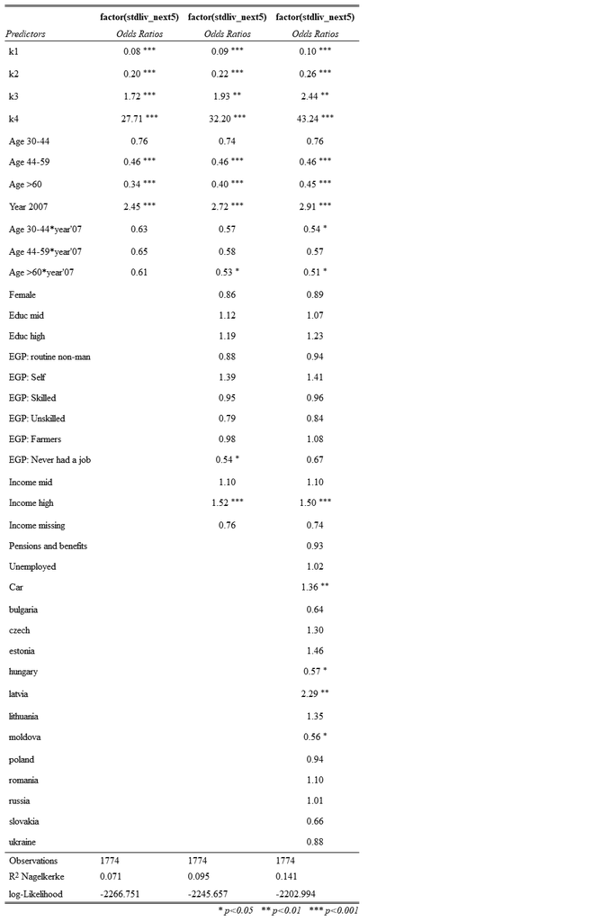

```r
webshot("results/Tbl5_rep.htm", file = "results/Tbl5_rep.png")
```